# Lab 5

## Lab 5 Write-up -- Aureliano Liu

#### Problem a : Download and load the data :

```python
%matplotlib inline
import pickle
import matplotlib.pyplot as plt
import scipy
from scipy import stats
import numpy as np
# open the file of interest, and use pickle loading
infile1 = open ("higgs_100000_pt_250_500.pkl",'rb')
higgs = pickle.load(infile1)
infile2 = open ("qcd_100000_pt_250_500.pkl",'rb')
bcg = pickle.load(infile2)
# list all keys of the files
print(higgs.keys())
print(bcg.keys())
plt.rcParams["figure.figsize"] = (20,15)
```

```
Index(['pt', 'eta', 'phi', 'mass', 'ee2', 'ee3', 'd2', 'angularity', 't1',
       't2', 't3', 't21', 't32', 'KtDeltaR'],
      dtype='object')
Index(['pt', 'eta', 'phi', 'mass', 'ee2', 'ee3', 'd2', 'angularity', 't1',
       't2', 't3', 't21', 't32', 'KtDeltaR'],
      dtype='object')
```

```python
# Print two variables, mass and d2, of the first 10 jets
for i in range(10):
 print(higgs['mass'][i],higgs['d2'][i])
```

```
125.15036485403486 1.2980200835589373
130.55267214662751 1.445626317832899
125.70306309880351 0.986596849742669
126.21585336608149 1.2184665392866647
132.18250371689544 1.2917844364435773
125.67653506886116 0.4343656746345235
127.65400794990293 0.9312049446719695
124.16656852260293 0.9493560863407668
122.13035265114684 3.0022665455324082
125.19144633816678 0.5539996032675585
```

```python
for i in range(10):
    print(higgs['eta'][i])
```

```
0.1370519332012567
-0.039156946405966994
-0.18113869350741718
0.2519857186430087
-1.9178121483210382
1.6789983031293292
-2.1232377315958573
1.5648436680643611
1.057998891521033
1.0767026119949465
```

#### Problem b : Data Explorations :

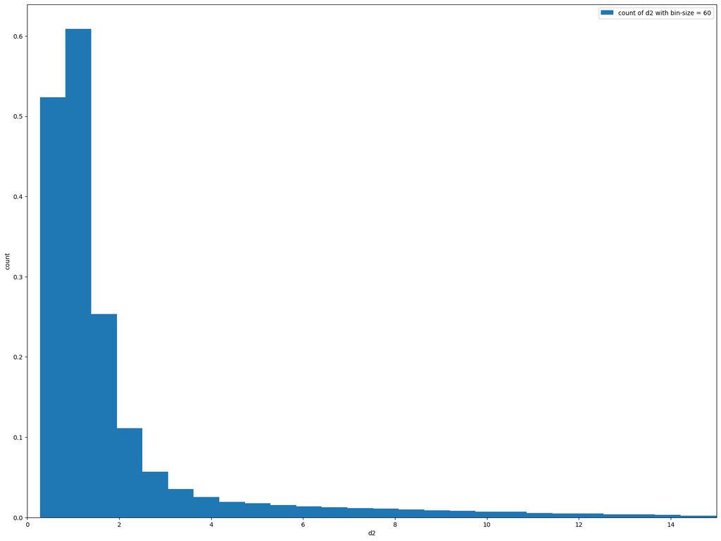

```python
fig,ax = plt.subplots()
ax.hist(higgs['d2'][:],bins = 60,density = True,label="count of d2 with bin-size = 60");
ax.set_xlabel("d2")
ax.set_ylabel("count")
ax.set_xlim(0,15)
ax.legend()
```

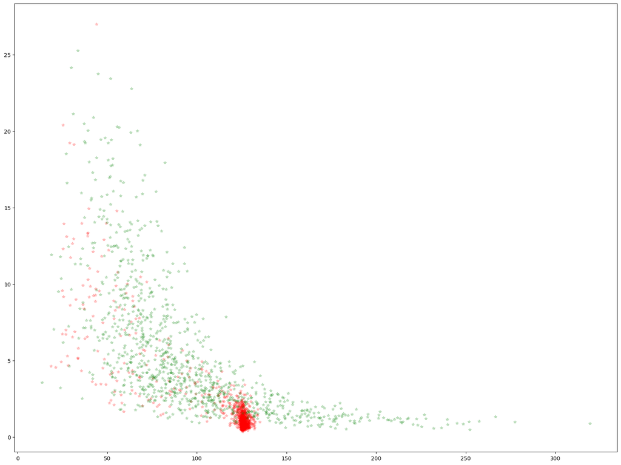

```python
fig,ax = plt.subplots()
s = slice(0,100000,100)
ax.plot(higgs['mass'][s],higgs['d2'][s],'r*',alpha = 0.2,label="higgs signal data")
ax.plot(bcg['mass'][s],bcg['d2'][s],'g*',alpha = 0.2,label="background data")
```

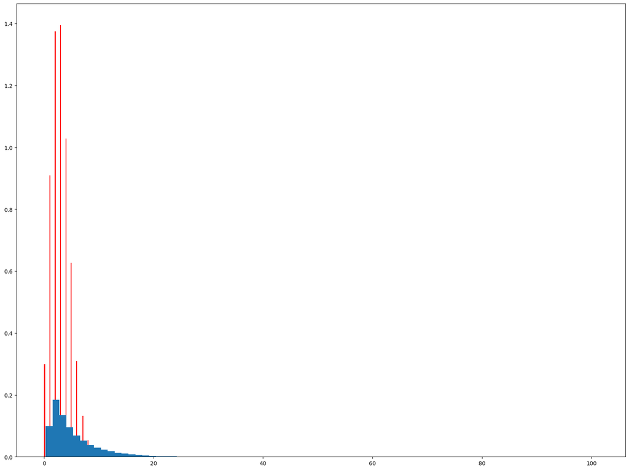

```python
num_points = 100000
fig1,ax1 = plt.subplots()
#ax1.plot(bcg['mass'][:],bcg['d2'][:],'g*',alpha = 0.2)
#ax1.plot(bcg['mass'][:],stats.poisson.pmf(bcg['mass'][:],5))
dist = stats.poisson(3)
vals = dist.rvs(num_points)
ax1.hist(vals, bins=80, density=True,color = 'r',label="Poisson");
ax1.hist(bcg['d2'][:],bins = 80,density= True);
```

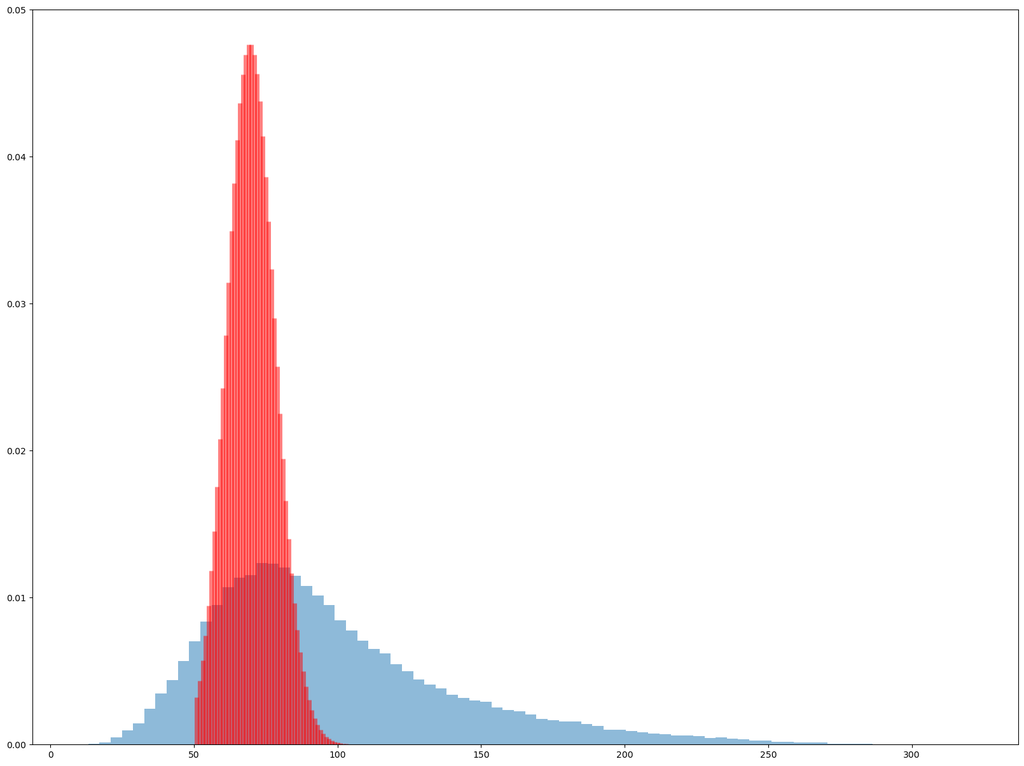

```python
mean = 70
fig2,ax2 = plt.subplots()
x = np.arange(stats.poisson.ppf(0.01, mean),stats.poisson.ppf(0.9999999999999999, mean))
pdf = stats.poisson.pmf(x, mean)
ax2.vlines(x, 0, stats.poisson.pmf(x, mean), colors='r', lw=5, alpha=0.5)
#ax2.plot(x,pdf,'b')
ax2.hist(bcg['mass'][:],bins = 80,density= True,alpha = 0.5);
```

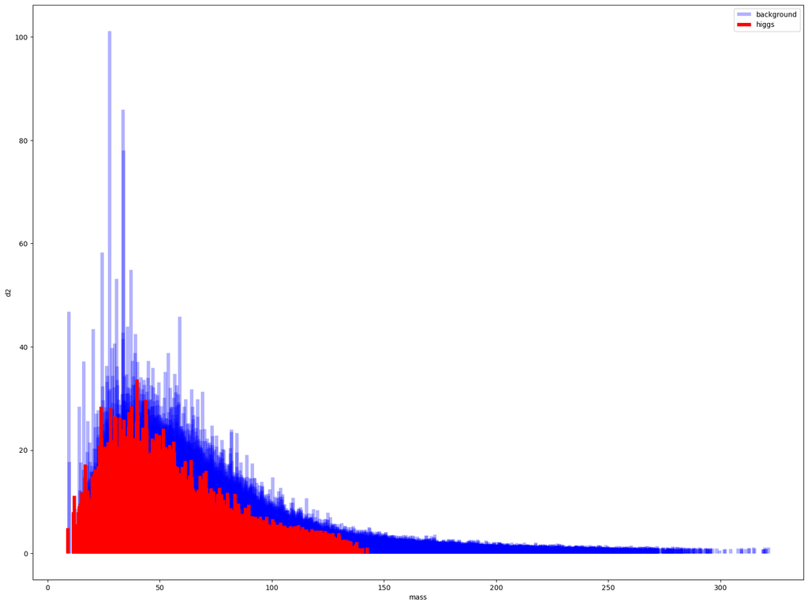

```python
fig, ax1 = plt.subplots(1, 1)
start = 0
end = 100000
ax1.vlines(bcg['mass'], 0,bcg['d2'], colors='b', linestyles='-', lw=5, alpha = 0.3,label="background")
ax1.vlines(higgs['mass'], 0, higgs['d2'], colors='r', linestyles='-', lw=5,label="higgs")
ax1.set_xlabel("mass")
ax1.set_ylabel("d2")
ax1.legend()
plt.show()
```

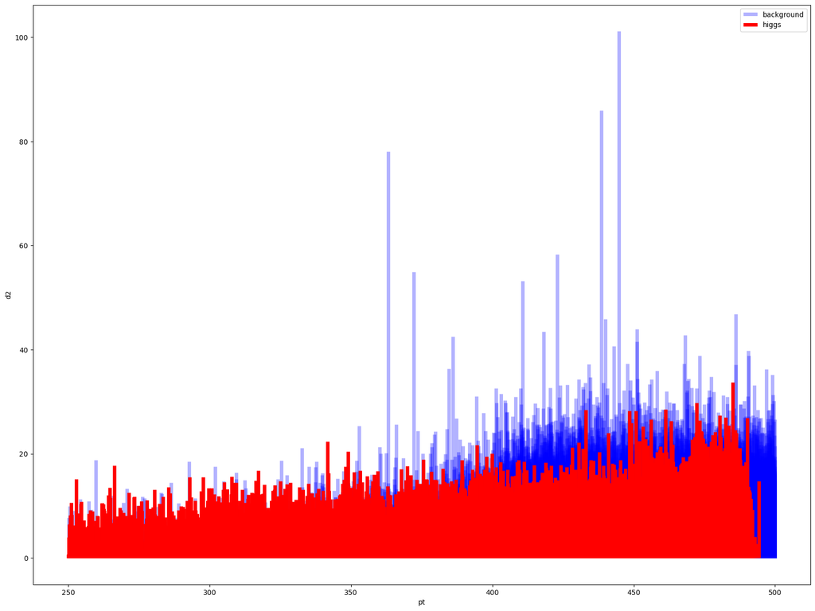

```python
fig, ax1 = plt.subplots(1, 1)
start = 0
end = 100000
ax1.vlines(bcg['pt'], 0, bcg['d2'], colors='b', linestyles='-', lw=5, alpha = 0.3,label="background")
ax1.vlines(higgs['pt'], 0, higgs['d2'], colors='r', linestyles='-', lw=5,label="higgs")
ax1.set_xlabel("pt")
ax1.set_ylabel("d2")
ax1.legend()
plt.show()
```

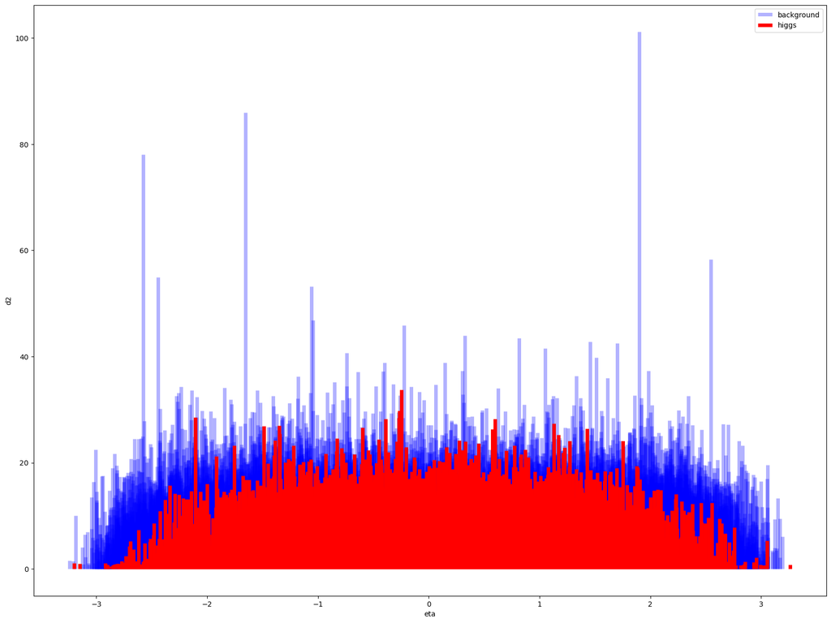

```python
fig, ax1 = plt.subplots(1, 1)
start = 0
end = 100000
ax1.vlines(bcg['eta'], 0, bcg['d2'], colors='b', linestyles='-', lw=5, alpha = 0.3,label="background")
ax1.vlines(higgs['eta'], 0, higgs['d2'], colors='r', linestyles='-', lw=5,label="higgs")
ax1.set_xlabel("eta")
ax1.set_ylabel("d2")
ax1.legend()
plt.show()
```

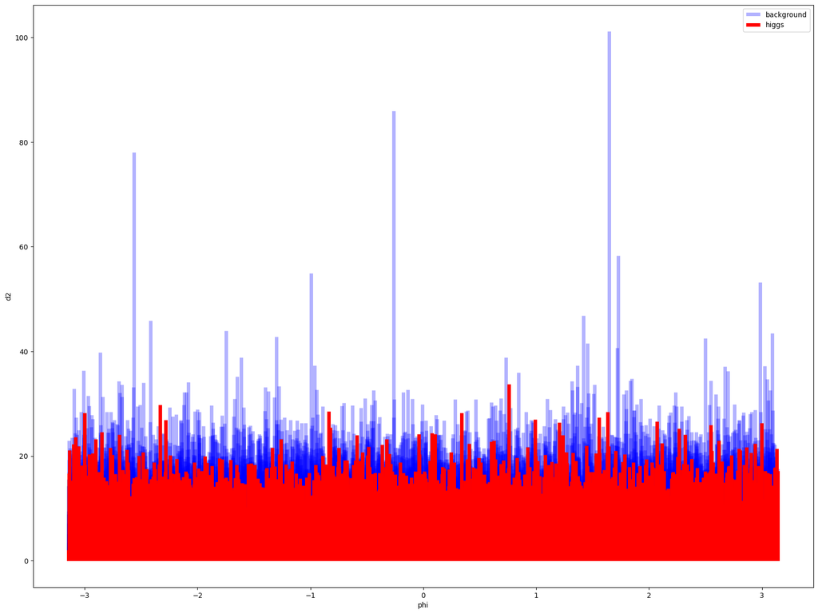

```python
fig, ax1 = plt.subplots(1, 1)
start = 0
end = 100000
ax1.vlines(bcg['phi'], 0, bcg['d2'], colors='b', linestyles='-', lw=5, alpha = 0.3,label="background")
ax1.vlines(higgs['phi'], 0, higgs['d2'], colors='r', linestyles='-', lw=5,label="higgs")
ax1.set_xlabel("phi")
ax1.set_ylabel("d2")
ax1.legend()
plt.show()
```

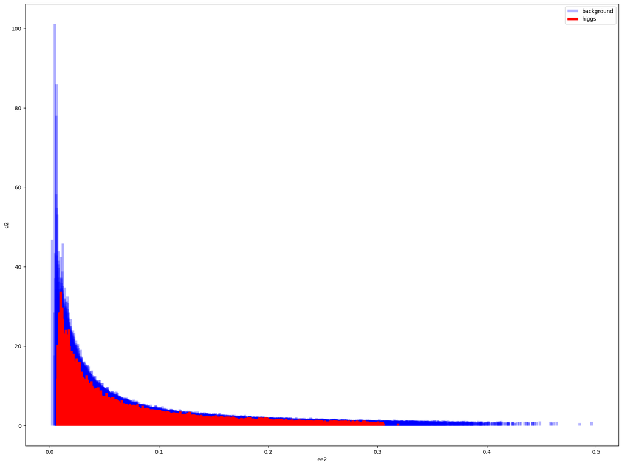

```python
fig, ax1 = plt.subplots(1, 1)
start = 0
end = 100000
ax1.vlines(bcg['ee2'], 0, bcg['d2'], colors='b', linestyles='-', lw=5, alpha = 0.3,label="background")
ax1.vlines(higgs['ee2'], 0, higgs['d2'], colors='r', linestyles='-', lw=5,label="higgs")
ax1.set_xlabel("ee2")
ax1.set_ylabel("d2")
ax1.legend()
plt.show()
```

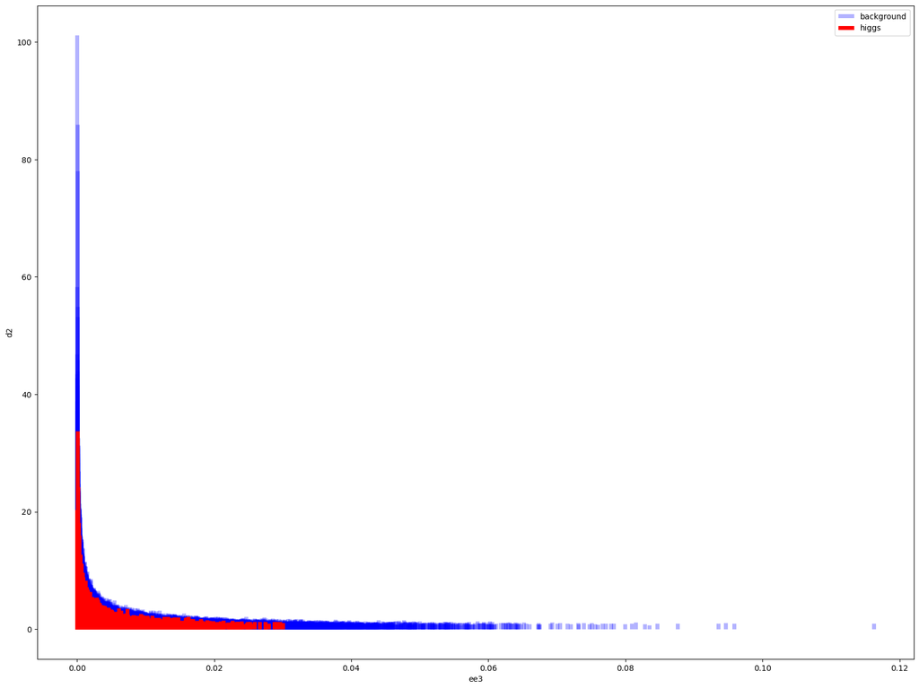

```python
fig, ax1 = plt.subplots(1, 1)
start = 0
end = 100000
ax1.vlines(bcg['ee3'], 0, bcg['d2'], colors='b', linestyles='-', lw=5, alpha = 0.3,label="background")
ax1.vlines(higgs['ee3'], 0, higgs['d2'], colors='r', linestyles='-', lw=5,label="higgs")
ax1.set_xlabel("ee3")
ax1.set_ylabel("d2")
ax1.legend()
plt.show()
```

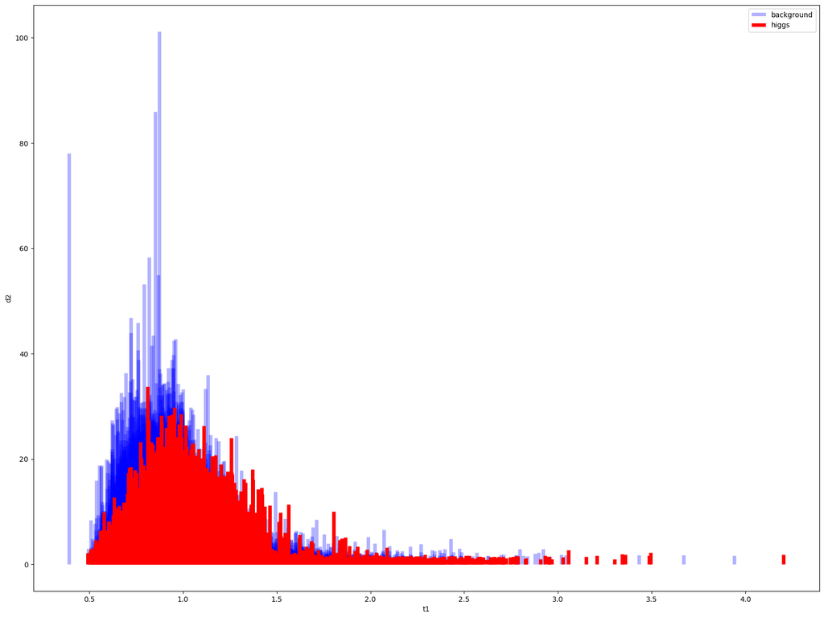

```python
fig, ax1 = plt.subplots(1, 1)
start = 0
end = 100000
ax1.vlines(bcg['t1'], 0, bcg['d2'], colors='b', linestyles='-', lw=5, alpha = 0.3,label="background")
ax1.vlines(higgs['t1'], 0, higgs['d2'], colors='r', linestyles='-', lw=5,label="higgs")
ax1.set_xlabel("t1")
ax1.set_ylabel("d2")
ax1.legend()
plt.show()
```

#### Question 1

From the plots above, we can figured out there are some cases that we cannot discriminate the signal distribution out of the background. For instance, the plot of feature "ee2" with respect to "d2" does not yield too much variations which could help us seperate one from another.

#### Question 2

Based on the plots we found from above, we can see there exist some correlations between features, for instance:

From the plot between feature "ee2" and "d2", we can see a very clear trend that the value of "ee2" has inverse correlation with the value of "d2" and such trend persists in both signal dataset and background dataset.

By carefully examining the source code, we can also find that there is correlation between the feature of "ee2", "ee3" and "d2". However, since their correlation involves more variables than just 2 where we can simply plot them out and see, we need to verify it as following:

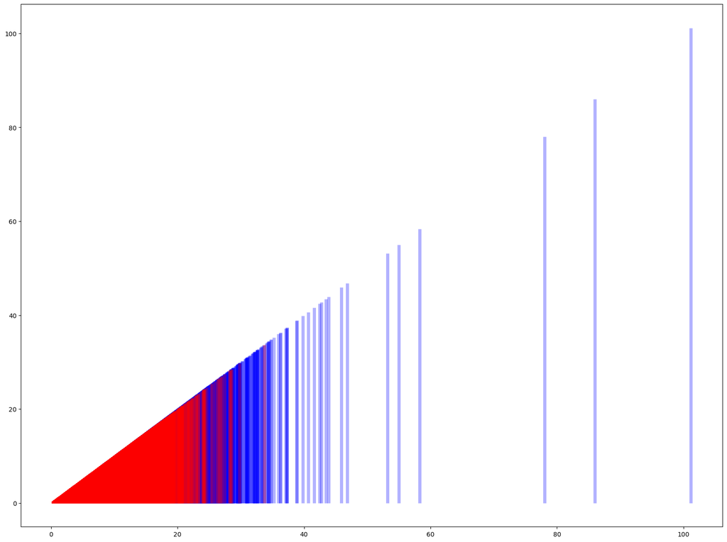

```python
fig, ax1 = plt.subplots(1, 1)
start = 0
end = 100000
ax1.vlines(bcg['ee3']/(bcg['ee2'])**3, 0, bcg['d2'], colors='b', linestyles='-', lw=5, alpha = 0.3)
ax1.vlines(higgs['ee3']/(higgs['ee2'])**3, 0, higgs['d2'], colors='r', linestyles='-', lw=5, alpha = 0.3)
plt.show()
```

Explanations of keys of data:

each "pt" refers to a jet's momentum, so we can also think it as the primary key of these datasets

From the plot above, we can clearly see a linear pattern that exists between these 3 varaibles, and the slope is 1.

eta : pseudorapidity

Phi : Azimuthal Angle

$t_n : n^{th} $subjettiness

$t_{21}$ : 2 to 1 subjettiness

$t_{32}$ : 3 to 2 subjettiness

mass : invariant mass

ee2: Ratio of 2 points generalized energgy correlation function \

ee3: Ratio of 3 points generalized energgy correlation function \

d2 : ee3 / ee2**3

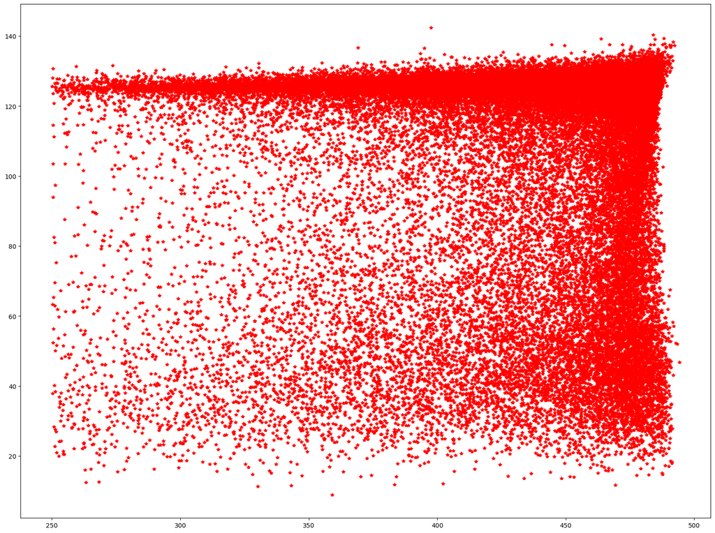

```python
fig,ax = plt.subplots()
ax.plot(higgs['pt'][:],higgs['mass'][:],'r*')
```

#### Question 3 :

```python
new_higgs = higgs['mass'][:]
res = (higgs['mass'][:] - min(higgs['mass'][:]))/(max(higgs['mass'][:]))-min(higgs['mass'][:])
sigma5 = 1/3.5e6
stats.poisson.ppf(1 - sigma5,3)
```

```
15.0
```

#### Question 4 :

After examining the data and their plots, we can try to drop { ee2, ee3, t2, t3, phi } terms to better the discovery sensitivity